# Exercise 5.3.4 - Ridge and Lasso Cross-Validation

W. Mangrobang

August 29, 2018

### Breast Cancer Data Set

##### **1. Implement the provided trial-and-error CV process with the breast cancer data as split previously to set lambda values for ridge and lasso regression.**

- *Note that the function `cv.glmnet()` will do cross validation over the lambda values for you, although not over the alpha values. You can choose to use this function or implement cross validation yourself.*
1. Split the data into training and test sets (80%/20% or otherwise):

```r
# load data
bc.all <- read.csv("/users/werlindo/dropbox/pacp/data/BreastCancerWisconsinDataSet.csv")

# create binarized target
bc.all$target[bc.all$diagnosis == "M"] = 1
bc.all$target[bc.all$diagnosis == "B"] = 0
bc.all$target <- as.factor(bc.all$target)  # This is to force the logistic regression to predict 0/1

# select variables available for training
bc.all <- bc.all[, setdiff(colnames(bc.all), c("diagnosis", "id", "X"))]

# split data into training vs testing; 80%/20%
set.seed(2425)

library(caret)  # get createDataPartition
train <- createDataPartition(bc.all$target, p = 0.8, list = FALSE)

# allocate datasets
bc.train <- bc.all[train, ]
bc.test <- bc.all[-train, ]
```

*The following steps we will use `cv.glmnet`*

2. Split the training data into n folds (for n-fold cross validation).
3. Select a list of values you want to test, e.g.:
- lambda = (0.01, 0.1, 0.5, 1)
- alpha = (0, 0.25, 0.5, 0.75, 1)

Note that if only performing ridge or lasso regression, you only need to worry about lambda.

4. For each pair of values (or single value for lasso or ridge):  
   A. Train the model on (n-1) folds of the training data using those values.  
   B. Calculate the prediction error on the remaining fold of training data.  
   C. Repeat n times for each fold in the training data (cross validation).  
   D. Calculate the average error rate across all iterations in the cross validation (cross validation error).
5. Take the pair of values that gives the lowest cross validation error.
6. Train a model on all of the training data using the optimal hyperparameters.
7. Test the model on the test data.

#### Ridge Regression Cross-Validation

We will use `cv.glmnet` to run the cross-validations.

For $\lambda$’s, we’ll use: `(0.01, 0.1, 0.5, 1, 10)`.

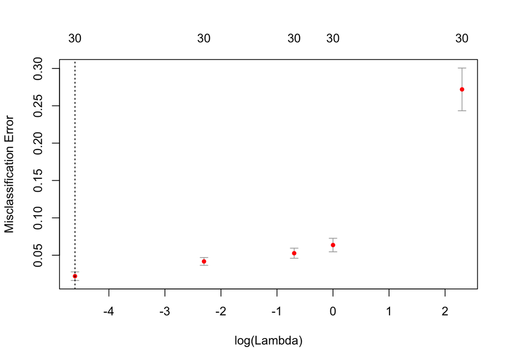

```r
library(glmnet) #regressions

# Set up the formula (model form)
# Know that target is last of 31 columns, so take 1:30
formula.lm <- as.formula(paste("target~",paste(colnames(bc.train[,c(1:30)]),collapse = "+")))

# Here is a clever way to create the data matrix. This one doesn't require keeping track of which columns contain the features.
X <- model.matrix(formula.lm, data = bc.train)

# Set up lamdbas
lambdas <- c(0.01, 0.1, 0.5, 1, 10)
?cv.glmnet

# Cross Validation
cvfit.r = cv.glmnet(X
                  , y = bc.train$target
                  , family = "binomial"
                  , type.measure = "class"
                  , alpha = 0 #Ridge
                  , lambda = lambdas
                  )
plot(cvfit.r)
```

Default number of folds, per the [documentation](https://www.rdocumentation.org/packages/glmnet/versions/2.0-16/topics/cv.glmnet), is `10`.

To get the $\lambda$ that gives minimum mean cross-validated error we can use `cvfit.r$lambda.min`; this $\lambda$ turns out to be `0.01`.

#### Lasso Regression Cross-Validation

Assuming same $\lambda$’s: `(0.01, 0.1, 0.5, 1, 10)`.

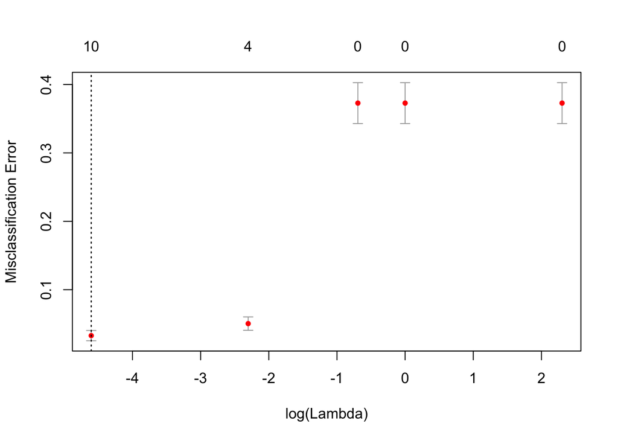

```r
cvfit.l = cv.glmnet(X
                  , y = bc.train$target
                  , family = "binomial"
                  , type.measure = "class"
                  , alpha = 1 #Lasso
                  , lambda = lambdas
                  )
plot(cvfit.l)
```

To get the $\lambda$ that gives minimum mean cross-validated error we can use `cvfit.l$lambda.min`; this $\lambda$ turns out to be `0.01` as well.

##### **2. Test both models on the test data and calculate the prediction error. Compare the results of the two models (including the coefficients). What do you notice?**

```r
# Get matrix input for test data
X.test <- model.matrix(formula.lm, data = bc.test)

# Get predictions from both cv sets for 'optimal' lambdas
res.ridge <- as.data.frame( as.double( predict(cvfit.r, newx = X.test, s = "lambda.min", type = "class") ) )
colnames(res.ridge) <- c('res.ridge')
res.lasso <- as.data.frame( as.double( predict(cvfit.l, newx = X.test, s = "lambda.min", type = "class") ) )
colnames(res.lasso) <- c('res.lasso')

# Bind it to the the testing set
bc.test <- cbind( bc.test, res.ridge, res.lasso )
str(bc.test)
```

```
## 'data.frame':    113 obs. of  33 variables:
##  $ radius_mean            : num  18 19.7 11.4 15.8 15.8 ...
##  $ texture_mean           : num  10.4 21.2 20.4 17.9 23.9 ...
##  $ perimeter_mean         : num  122.8 130 77.6 103.6 103.7 ...
##  $ area_mean              : num  1001 1203 386 781 783 ...
##  $ smoothness_mean        : num  0.1184 0.1096 0.1425 0.0971 0.084 ...
##  $ compactness_mean       : num  0.278 0.16 0.284 0.129 0.1 ...
##  $ concavity_mean         : num  0.3001 0.1974 0.2414 0.0995 0.0994 ...
##  $ concave.points_mean    : num  0.1471 0.1279 0.1052 0.0661 0.0536 ...
##  $ symmetry_mean          : num  0.242 0.207 0.26 0.184 0.185 ...
##  $ fractal_dimension_mean : num  0.0787 0.06 0.0974 0.0608 0.0534 ...
##  $ radius_se              : num  1.095 0.746 0.496 0.506 0.403 ...
##  $ texture_se             : num  0.905 0.787 1.156 0.985 1.078 ...
##  $ perimeter_se           : num  8.59 4.58 3.44 3.56 2.9 ...
##  $ area_se                : num  153.4 94 27.2 54.2 36.6 ...
```

[output cut: 19 more lines]

```r
#We'll use a custom function for accuracy.
accuracy = function(truth, pred) {
  # confusion matrix
  cmat = table(truth, pred)
  sum(diag(cmat))/sum(cmat)
}

#create empty dataframe to store accuracy results
acc <- data.frame( model=as.character(), accuracy=as.double())

#Calc accuracy
acc <- rbind(acc, data.frame( model='Ridge', accuracy=accuracy(bc.test$target, bc.test$res.ridge)))
acc <- rbind(acc, data.frame( model='Lasso', accuracy=accuracy(bc.test$target, bc.test$res.lasso)))

#Make a table
library(kableExtra) #kable

# Let's make a pretty table
acc.tbl <- acc %>%
  kable() %>%
  kable_styling(bootstrap_options = "striped", font_size = 10, full_width = FALSE, position = "left") %>%
  row_spec(1, bold = T, color = "white", background = "orange")
acc.tbl
```

| model | accuracy |
| --- | --- |
| Ridge | 0.9734513 |
| Lasso | 0.9557522 |

Both models had `lambda.min` of `0.01`, which makes for pretty straighforward comparison. Given that we see that the ridge regression is just a little more accurate on the test set; `0.9734513` vs `0.9557522` for lasso.

As we’ve seen [before](https://gitamoveon.github.io/PACP/Ex_5_3_3.html), as we alpha increases, more variables/features get pushed to zero (implicit variable selection); the potential downside is that less information could lead to less accuracy.

The following is a heatmap of the coefficients for the ridge and lasso regressions, for comparison.

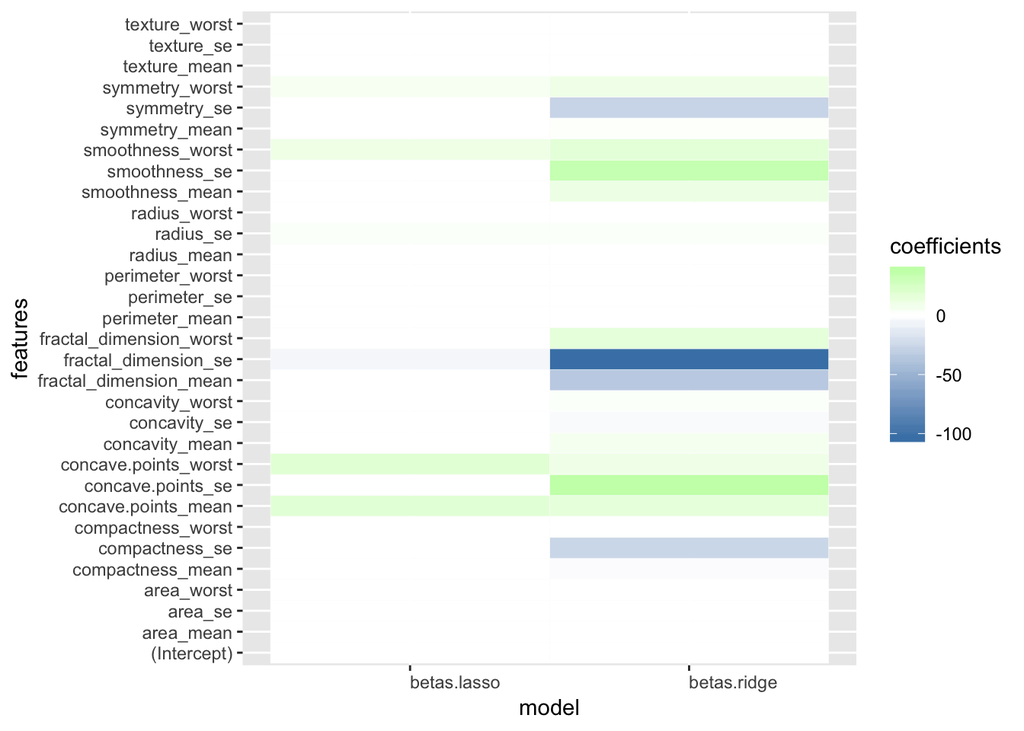

```r
# Get the cv fits
fit.ridge <- cvfit.r$glmnet.fit
fit.lasso <- cvfit.l$glmnet.fit

# Get just the betas (coefficients)
betas.ridge <- as.matrix(fit.ridge$beta)
betas.lasso <- as.matrix(fit.lasso$beta)

# Get just the coefficients where lambda is lambda.min
betas.ridge <- betas.ridge[,which(fit.ridge$lambda==cvfit.r$lambda.min)]
betas.lasso <- betas.lasso[,which(fit.lasso$lambda==cvfit.l$lambda.min)]

df.betas <- as.data.frame(cbind(betas.ridge,betas.lasso))

library(tidyverse) #rownames_to_column
df.betas <- rownames_to_column(df.betas)
colnames(df.betas)[1] <- 'features'

#Melt it
df.betas.melted <- gather( df.betas, key = model, value = coefficients, -features)

#Plot heatmap
p <- ggplot(df.betas.melted, aes(x=model, y=features)) + geom_tile(aes(fill = coefficients),
     colour = "white") + scale_fill_gradient2(low = "steelblue",
     high = "green", mid = "white") +
     theme(axis.text.x = element_text(angle = 0, hjust = 0))
    # geom_text(aes(label=coefficients))
p
```

Note that there is far more `white` for the lasso results, i.e. more of the coefficients got pushed to `0`.

##### **3. Also compare the results to running ordinary least squares regression on the training data and calculating prediction error on the test data. What do you notice?**

```r
# Recreate numeric versions of target variable
bc.train$target.num[bc.train$target == "1"] <- 1
bc.train$target.num[bc.train$target == "0"] <- 0

bc.test$target.num[bc.test$target == "1"] <- 1
bc.test$target.num[bc.test$target == "0"] <- 0

# Rewrite formula with numeric target
formula.ols <- as.formula(paste("target.num~",paste(colnames(bc.train[,c(1:30)]),collapse = "+")))

# Run OLS
ols <- lm( formula.ols, bc.train)

#make test predictions
pred.ols <- predict(ols, bc.test, type='response')
pred.ols
```

```
##            1            3            4           12           14
##  1.234119442  1.208774665  1.414654324  0.902486766  0.450817271
##           21           26           30           33           43
## -0.038805804  1.254361242  0.526480995  1.184769882  1.241966613
##           45           53           57           62           65
##  0.671478048  0.055832823  1.013580440 -0.126896707  0.900282807
##           68           70           80           82           83
##  0.076386215  0.057344646  0.044541513  0.629414238  1.474011626
##           96          100          104          108          109
##  1.015629995  0.484705436 -0.031678166 -0.019052806  1.686802110
##          111          113          114          115          121
##  0.061942627  0.255492390 -0.107418723 -0.103963720  0.035277289
##          125          127          129          139          140
##  0.043906682  0.543522943  0.328494478  1.121468331 -0.036380796
##          141          145          149          152          156
## -0.246492466 -0.162552409  0.306616126  0.157277375  0.139598288
##          158          161          164          169          187
##  0.226736828  0.137955634  0.185902752  1.190648574  0.559483874
##          188          192          198          208          209
##  0.107319701  0.192927767  0.398293376  0.586970311  0.382155908
##          216          219          223          236          238
##  0.425965739  1.012340799 -0.059200930  0.190882613  0.778416598
##          242          250          256          262          265
## -0.085730171  0.020593685  0.432221476  0.401184386  0.775289046
##          272          277          285          302          310
## -0.039270904 -0.114362406  0.002953104  0.045255341 -0.003651509
##          311          312          320          321          335
##  0.045732919  0.164978690  0.010362646  0.074131841  0.072077901
##          336          340          345          353          356
##  0.964492878  1.263895065  0.155319472  1.489133500  0.125575693
##          361          377          379          384          390
## -0.031635203 -0.001871245  0.178768099  0.091893239  1.018036761
##          394          396          398          401          404
##  1.359958755  0.115808775 -0.010221427  1.074677342 -0.009768754
##          405          409          414          424          429
##  0.022813483  0.828706548  0.420207322  0.273180387 -0.139159716
##          435          440          442          478          479
##  0.203647891  0.031564199  0.810786406  0.054267001 -0.069112026
##          491          498          500          510          511
##  0.220669304  0.111450447  1.014534929  0.819612340  0.056329653
##          514          515          523          524          529
##  0.265346537  0.332601047 -0.131772589  0.281166287  0.399670219
##          535          538          543          545          554
## -0.098526635  0.250684820  0.347004604  0.020467845 -0.092892413
##          563          565          568
##  1.257593469  1.388692745  1.792265142
```

OLS is not appropriate for predicting on binary variables. Looking at the results we see values that are ’kind of around" 0 and 1, but without some sort of rubric, we can’t really translate this to final predictions, e.g. which should be considered 0’s and 1’s. Logistic regression is more approriate.

If we revisit the [non-regularized logistic regressions we’ve performed prior](https://gitamoveon.github.io/PACP/Ex_5_3_1.html), we see that the accuracy rate is around 96%, in the neighborhood of our above results.

Looking at the coefficients:

```r
summary(ols)
```

```
##
## Call:
## lm(formula = formula.ols, data = bc.train)
##
## Residuals:
##      Min       1Q   Median       3Q      Max
## -0.54439 -0.15315 -0.02893  0.12904  0.80651
##
## Coefficients:
##                           Estimate Std. Error t value Pr(>|t|)
## (Intercept)             -1.8599871  0.4781221  -3.890 0.000116 ***
## radius_mean             -0.0343965  0.1882290  -0.183 0.855091
## texture_mean             0.0075004  0.0084917   0.883 0.377590
## perimeter_mean          -0.0068205  0.0274680  -0.248 0.804015
## area_mean                0.0003921  0.0005713   0.686 0.492794
## smoothness_mean          0.6576678  2.1377899   0.308 0.758508
## compactness_mean        -4.0604658  1.4807883  -2.742 0.006363 **
## concavity_mean           3.6291647  1.1995241   3.026 0.002633 **
## concave.points_mean      1.4947583  2.1466252   0.696 0.486603
## symmetry_mean           -0.2934662  0.8088173  -0.363 0.716909
## fractal_dimension_mean  -0.8797834  6.2813773  -0.140 0.888677
## radius_se                0.4443556  0.3427472   1.296 0.195523
## texture_se               0.0058848  0.0391888   0.150 0.880705
## perimeter_se            -0.0224480  0.0440786  -0.509 0.610826
## area_se                 -0.0013254  0.0015199  -0.872 0.383672
## smoothness_se           13.9857751  6.8890474   2.030 0.042964 *
## compactness_se          -0.4737599  2.4036030  -0.197 0.843840
## concavity_se            -5.3803941  1.3878835  -3.877 0.000123 ***
## concave.points_se       15.7796572  6.0108446   2.625 0.008972 **
## symmetry_se              1.1585618  2.9765156   0.389 0.697298
## fractal_dimension_se    -6.6971940 12.3681800  -0.541 0.588457
## radius_worst             0.1739133  0.0623228   2.791 0.005499 **
## texture_worst            0.0034293  0.0074328   0.461 0.644765
## perimeter_worst          0.0006955  0.0064679   0.108 0.914419
## area_worst              -0.0009634  0.0003453  -2.790 0.005511 **
## smoothness_worst        -0.0344537  1.5251971  -0.023 0.981988
## compactness_worst        0.4152832  0.4178163   0.994 0.320819
## concavity_worst          0.0909471  0.3001939   0.303 0.762068
## concave.points_worst    -0.1650302  1.0020891  -0.165 0.869269
## symmetry_worst           0.7634369  0.5316969   1.436 0.151781
## fractal_dimension_worst  4.5768307  2.5937224   1.765 0.078353 .
## ---
## Signif. codes:  0 '***' 0.001 '**' 0.01 '*' 0.05 '.' 0.1 ' ' 1
##
## Residual standard error: 0.2317 on 425 degrees of freedom
## Multiple R-squared:  0.7861, Adjusted R-squared:  0.771
## F-statistic: 52.06 on 30 and 425 DF,  p-value: < 2.2e-16
```

…it’s interesting to note that the variables that are marked as significant under OLS, don’t really align nicely with the more ‘resistant’ variables under our regularized regressions, i.e. the ones who ‘resist’ being pushed to zero.